# Low-input RNA-seq from human vastus lateralis - Kallisto DESeq2

FvW Lab

Data analysis: Paulo Jannig | Karolinska Institutet

Last update: October 31, 2025

# 1 Low-input RNA-seq from human vastus lateralis

*Data set:* Low-input RNA-seq from human vastus lateralis

*Additional data:* For each sample, metadata include the tissue input amount (µg) and a pseudonymized subject ID. Sequencing quality metrics (read counts, mapping rates, and duplication levels) are stored in separate summary tables.

*Objective:* To assess RNA yield, sequencing quality, and transcriptome analyzability from skeletal muscle samples obtained through a low-input microbiopsy approach. The study aims to determine the minimal tissue input required for robust RNA-seq analysis in human skeletal muscle.

*Human genome:* [GRCh38 (release-102)](https://www.ensembl.org/Homo_sapiens/Info/Index)

*Genome FASTA file:* Homo_sapiens.GRCh38.dna.primary_assembly.fa.gz

*GTF annotation file:* Homo_sapiens.GRCh38.102.gtf.gz

*Transcriptome (cDNA) FASTA file:* Homo_sapiens.GRCh38.cdna.all.fa.gz

# 2 Setup environment

```r
knitr::opts_chunk$set(echo = TRUE, warning = FALSE, message = FALSE)

## set work dir as this script's dir
#setwd(dirname(rstudioapi::getSourceEditorContext()$path))

# define variables ==========================================
filename_prefix <- "" # leave empty if not necessary
species <- "human" # mouse, human, pig, rat
ensembl_version <- 102 # define ensembl release version

file_formats <- list(
  #"jpg",
  "pdf"
)

# load libraries
required_Packages_Install <- c(
  "tidyverse",
  "DT",
  "DESeq2",
  "vsn",
  "biomaRt",
  "tximport",
  "RColorBrewer",
  "ggrepel",
  "pheatmap",
  "readxl",
  "writexl"
)

for (Package in required_Packages_Install) {
  if (!require(Package, character.only = TRUE)) {
    BiocManager::install(Package, dependencies = TRUE)
  }
  library(Package, character.only = TRUE)
}
# source custom functions
source("load_functions.R") # source custom functions
```

# 3 Data analysis

## 3.1 Metadata

Read sample info column names:

```r
colnames(read.csv("../01_metadata/metadata.csv",
                  sep = ";",
                  header = TRUE
))
```

```
## [1] "bam"       "sample"    "subject"   "input"     "weight_ug"
```

Create metadata.csv:

```r
metadata <- read.csv("../01_metadata/metadata.csv",
                  sep = ";",
                  header = TRUE) %>%
  mutate(
    sample = as.factor(paste0(subject,"_",input)),
    subject = as.factor(subject),
    input = as.factor(input)) %>%
  as.data.frame()

files_path <- "../02_results/kallisto/"
files <- list.files(files_path)

metadata <- metadata %>%
  mutate(abundanceFile = paste0(
    files_path,
    files,
    "/abundance.h5"
  )) %>%
  mutate(tpmFile = paste0(
    files_path,
    files,
    "/abundance.tsv"
  )) %>%
  relocate(sample, abundanceFile, subject, .before = everything())
```

```r
filename <- "metadata_kallisto"
write.csv(metadata, paste0(
  "../01_metadata/",
  filename_prefix,
  filename,
  ".csv"
),
row.names = F, quote = F
)

saveRDS(metadata, paste0(
  "../01_metadata/",
  filename_prefix,
  filename,
  ".RDS"
))
```

### 3.1.1 Metadata table

```r
filename <- "metadata"
metadata %>% DT::datatable(
  extensions = "Buttons",
  options = list(
    scrollX = TRUE,
    pageLength = nrow(metadata),
    dom = "Blfrtip",
    buttons = list(
      list(extend = "csv", filename = paste0(filename_prefix, filename)),
      list(extend = "excel", filename = paste0(filename_prefix, filename))
    )
  )
)
```

|  | sample | abundanceFile | subject | bam | input | weight_ug | tpmFile |
| --- | --- | --- | --- | --- | --- | --- | --- |
| 1 | V2_10 | ../02_results/kallisto/P28759_101_S26_L002/abundance.h5 | V2 | P28759_101_S26.Aligned.sortedByCoord.out.bam | 10 | 11 | ../02_results/kallisto/P28759_101_S26_L002/abundance.tsv |
| 2 | V2_30 | ../02_results/kallisto/P28759_102_S27_L002/abundance.h5 | V2 | P28759_102_S27.Aligned.sortedByCoord.out.bam | 30 | 26,4 | ../02_results/kallisto/P28759_102_S27_L002/abundance.tsv |
| 3 | V2_50 | ../02_results/kallisto/P28759_103_S28_L002/abundance.h5 | V2 | P28759_103_S28.Aligned.sortedByCoord.out.bam | 50 | 52,2 | ../02_results/kallisto/P28759_103_S28_L002/abundance.tsv |
| 4 | V2_100 | ../02_results/kallisto/P28759_104_S29_L002/abundance.h5 | V2 | P28759_104_S29.Aligned.sortedByCoord.out.bam | 100 | 97,4 | ../02_results/kallisto/P28759_104_S29_L002/abundance.tsv |
| 5 | V2_250 | ../02_results/kallisto/P28759_105_S30_L002/abundance.h5 | V2 | P28759_105_S30.Aligned.sortedByCoord.out.bam | 250 | 254 | ../02_results/kallisto/P28759_105_S30_L002/abundance.tsv |
| 6 | V2_500 | ../02_results/kallisto/P28759_106_S31_L002/abundance.h5 | V2 | P28759_106_S31.Aligned.sortedByCoord.out.bam | 500 | 505 | ../02_results/kallisto/P28759_106_S31_L002/abundance.tsv |
| 7 | V4_10 | ../02_results/kallisto/P28759_107_S32_L002/abundance.h5 | V4 | P28759_107_S32.Aligned.sortedByCoord.out.bam | 10 | 10,6 | ../02_results/kallisto/P28759_107_S32_L002/abundance.tsv |
| 8 | V4_30 | ../02_results/kallisto/P28759_108_S33_L002/abundance.h5 | V4 | P28759_108_S33.Aligned.sortedByCoord.out.bam | 30 | 26,5 | ../02_results/kallisto/P28759_108_S33_L002/abundance.tsv |
| 9 | V4_50 | ../02_results/kallisto/P28759_109_S34_L002/abundance.h5 | V4 | P28759_109_S34.Aligned.sortedByCoord.out.bam | 50 | 54,9 | ../02_results/kallisto/P28759_109_S34_L002/abundance.tsv |
| 10 | V4_100 | ../02_results/kallisto/P28759_110_S35_L002/abundance.h5 | V4 | P28759_110_S35.Aligned.sortedByCoord.out.bam | 100 | 104 | ../02_results/kallisto/P28759_110_S35_L002/abundance.tsv |

[output cut: 13 more lines]

## 3.2 Create transcript2gene mapping

```r
transcripts <- read.csv(metadata$tpmFile[1],
  sep = "\t") %>%
  dplyr::rename(ensembl_transcript_id_version = target_id) %>%
  mutate(ensembl_transcript_id = str_remove(ensembl_transcript_id_version, "\\..*"))

annotation <- getBM(filters = "ensembl_transcript_id",
                       attributes = c("ensembl_transcript_id",
                                      "ensembl_gene_id",
                                      symbol,
                                      "chromosome_name",
                                      "gene_biotype"),
                       values = transcripts$ensembl_transcript_id,
                       mart = useEnsembl("ensembl",
                                         dataset = dataset,
                                         #mirror = "useast",
                                         version = ensembl_version)
) %>% dplyr::filter(!duplicated(ensembl_transcript_id))

# Replace empty symbol with ensembl_transcript_id
symbol_char <- as.character(symbol)
empty_indices <- annotation[, symbol_char] == ""
annotation[empty_indices, symbol_char] <- annotation[empty_indices, "ensembl_transcript_id"]

annotation_tx2gene <- annotation %>%
  distinct(ensembl_gene_id, .keep_all = TRUE)

transcript2gene <- left_join(annotation, transcripts,
                          by = "ensembl_transcript_id") %>%
  dplyr::select("ensembl_transcript_id_version", "ensembl_gene_id")
```

Save biomaRt annotation

```r
filename <- "biomart_annotation_kallisto"
write.csv(annotation, paste0(
  "../02_results/deseq2/",
  filename_prefix,
  filename,
  ".csv"
),
row.names = F, quote = F
)

saveRDS(annotation, paste0(
  "../02_results/deseq2/",
  filename_prefix,
  filename,
  ".RDS"
))
```

```
## Saved file: ../02_results/deseq2/biomart_annotation_kallisto.csv
```

Save transcript2gene mapping

```r
filename <- "transcript2gene"
write.csv(transcript2gene, paste0(
  "../02_results/deseq2/",
  filename_prefix,
  filename,
  ".csv"
),
row.names = F, quote = F
)

saveRDS(transcript2gene, paste0(
  "../02_results/deseq2/",
  filename_prefix,
  filename,
  ".RDS"
))
```

## 3.3 Import Kallisto data

### 3.3.1 Loading expression estimates

```r
files <- metadata$abundanceFile
names(files) <- metadata$sample
files
```

```
##                                                     V2_10
## "../02_results/kallisto/P28759_101_S26_L002/abundance.h5"
##                                                     V2_30
## "../02_results/kallisto/P28759_102_S27_L002/abundance.h5"
##                                                     V2_50
## "../02_results/kallisto/P28759_103_S28_L002/abundance.h5"
##                                                    V2_100
## "../02_results/kallisto/P28759_104_S29_L002/abundance.h5"
##                                                    V2_250
## "../02_results/kallisto/P28759_105_S30_L002/abundance.h5"
##                                                    V2_500
## "../02_results/kallisto/P28759_106_S31_L002/abundance.h5"
##                                                     V4_10
## "../02_results/kallisto/P28759_107_S32_L002/abundance.h5"
##                                                     V4_30
## "../02_results/kallisto/P28759_108_S33_L002/abundance.h5"
##                                                     V4_50
## "../02_results/kallisto/P28759_109_S34_L002/abundance.h5"
##                                                    V4_100
## "../02_results/kallisto/P28759_110_S35_L002/abundance.h5"
##                                                    V4_250
## "../02_results/kallisto/P28759_111_S36_L002/abundance.h5"
##                                                     V3_10
## "../02_results/kallisto/P28759_112_S37_L002/abundance.h5"
##                                                    V4_500
## "../02_results/kallisto/P28759_113_S38_L002/abundance.h5"
##                                                     V3_50
## "../02_results/kallisto/P28759_115_S39_L002/abundance.h5"
##                                                    V3_100
## "../02_results/kallisto/P28759_116_S40_L002/abundance.h5"
##                                                    V3_250
## "../02_results/kallisto/P28759_117_S41_L002/abundance.h5"
##                                                    V3_500
## "../02_results/kallisto/P28759_118_S42_L002/abundance.h5"
##                                                     V1_10
## "../02_results/kallisto/P28759_119_S43_L002/abundance.h5"
##                                                     V1_30
## "../02_results/kallisto/P28759_120_S44_L002/abundance.h5"
##                                                     V1_50
## "../02_results/kallisto/P28759_121_S45_L002/abundance.h5"
##                                                    V1_100
## "../02_results/kallisto/P28759_122_S46_L002/abundance.h5"
##                                                    V1_250
## "../02_results/kallisto/P28759_123_S47_L002/abundance.h5"
##                                                    V1_500
## "../02_results/kallisto/P28759_124_S48_L002/abundance.h5"
```

```r
# transcript-level estimates
txi.kallisto <- tximport(files, type = "kallisto",
                         txOut = TRUE)
count_data <- as.data.frame(txi.kallisto$counts)
head(count_data)
```

```
##                   V2_10 V2_30 V2_50 V2_100 V2_250 V2_500 V4_10 V4_30 V4_50
## ENST00000631435.1     0     0     0      0      0      0     0     0     0
## ENST00000415118.1     0     0     0      0      0      0     0     0     0
## ENST00000434970.2     0     0     0      0      0      0     0     0     0
## ENST00000448914.1     0     0     0      0      0      0     0     0     0
## ENST00000632684.1     0     0     0      0      0      0     0     0     0
## ENST00000632524.1     0     0     0      0      0      0     0     0     0
##                   V4_100 V4_250 V3_10 V4_500 V3_50 V3_100 V3_250 V3_500 V1_10
## ENST00000631435.1      0      0     0      0     0      0      0      0     0
## ENST00000415118.1      0      0     0      0     0      0      0      0     0
## ENST00000434970.2      0      0     0      0     0      0      0      0     0
## ENST00000448914.1      0      0     0      0     0      0      0      0     0
## ENST00000632684.1      0      0     0      0     0      0      0      0     0
## ENST00000632524.1      0      0     0      0     0      0      0      0     0
##                   V1_30 V1_50 V1_100 V1_250 V1_500
## ENST00000631435.1     0     0      0      0      0
## ENST00000415118.1     0     0      0      0      0
## ENST00000434970.2     0     0      0      0      0
## ENST00000448914.1     0     0      0      0      0
## ENST00000632684.1     0     0      0      0      0
## ENST00000632524.1     0     0      0      0      0
```

```r
# gene-level estimates
txi.kallisto_tx2gene <- tximport(files, type = "kallisto",
                                 tx2gene = transcript2gene,
                                 txOut = FALSE)
count_data_tx2gene <- as.data.frame(txi.kallisto_tx2gene$counts)
```

```r
filename <- "txi.kallisto_tx2gene"

saveRDS(txi.kallisto_tx2gene, paste0(
  "../02_results/deseq2/",
  filename_prefix,
  filename,
  ".RDS"
))
```

### 3.3.2 Loading TPM data

```r
# Create data frame for tpm data
tpm_data <- as.data.frame(txi.kallisto_tx2gene$abundance) %>%
    rownames_to_column("ensembl_gene_id")

cat("Total number of genes:",
    length(unique(tpm_data$ensembl_gene_id)),
    "\n")
```

```
## Total number of genes: 40488
```

```r
# merge with GTF annotation
tpm_data <- left_join(tpm_data,
  annotation_tx2gene,
  by = "ensembl_gene_id"
) %>%
  relocate(symbol, chromosome_name, gene_biotype,
           .after = ensembl_gene_id)
colnames(tpm_data)
```

```
##  [1] "ensembl_gene_id"       "hgnc_symbol"           "chromosome_name"
##  [4] "gene_biotype"          "V2_10"                 "V2_30"
##  [7] "V2_50"                 "V2_100"                "V2_250"
## [10] "V2_500"                "V4_10"                 "V4_30"
## [13] "V4_50"                 "V4_100"                "V4_250"
## [16] "V3_10"                 "V4_500"                "V3_50"
## [19] "V3_100"                "V3_250"                "V3_500"
## [22] "V1_10"                 "V1_30"                 "V1_50"
## [25] "V1_100"                "V1_250"                "V1_500"
## [28] "ensembl_transcript_id"
```

Save tpm data

```r
filename <- "kallisto_tpm"
write.csv(tpm_data, paste0(
  "../02_results/deseq2/",
  filename_prefix,
  filename,
  ".csv"
),
row.names = F, quote = F
)

saveRDS(tpm_data, paste0(
  "../02_results/deseq2/",
  filename_prefix,
  filename,
  ".RDS"
))
```

```
## Saved file: ../02_results/deseq2/kallisto_tpm.csv
```

## 3.4 DESeq2

```r
dds <- DESeqDataSetFromTximport(txi.kallisto_tx2gene,
  colData = metadata,
  design = ~ subject + input
)

dds <- estimateSizeFactors(dds)
nrow(dds)
```

```
## [1] 40488
```

### 3.4.1 Filtering low counts

```r
# Check number of genes with zero counts
table(rowSums(assay(dds, "counts")) == 0)
```

```
##
## FALSE  TRUE
## 38855  1633
```

```r
#dds <- dds[rowSums(counts(dds)) >= 1, ] ## remove genes with zero counts
#dds <- dds[rowSums(counts(dds) >= 10), ] ## remove genes with less than 10 counts across all samples
#dds <- dds[rowSums(counts(dds) >= 5 ) >= 3] ## remove genes where less than 3 samples with normalized counts greater than or equal to 5.

#Pre-filtering
smallestGroupSize <- metadata %>%
  dplyr::group_by(subject) %>%
  dplyr::summarise(samples = dplyr::n()) %>%
  pull(samples) %>%
  min()

#keep <- rowSums(counts(dds, normalized=TRUE) >= 10) >= smallestGroupSize ## remove genes where less than "smallestGroupSize" samples with normalized counts greater than or equal to 10.
keep <- rowSums(counts(dds, normalized=TRUE)) >= 1 ## remove genes with zero counts
dds <- dds[keep,]
dim(dds)
```

```
## [1] 38462    23
```

### 3.4.2 Relevel

```r
levels(dds$subject)
```

```
## [1] "V1" "V2" "V3" "V4"
```

```r
levels(dds$input)
```

```
## [1] "10"  "30"  "50"  "100" "250" "500"
```

```r
# dds$input <- relevel(dds$input, ref = "Sham")
dds$input <- factor(dds$input,
  levels = c(
    "10",
    "30",
    "50",
    "100",
    "250",
    "500"
  )
)
levels(dds$input)
```

```
## [1] "10"  "30"  "50"  "100" "250" "500"
```

### 3.4.3 standard analysis

```r
dds <- DESeq(dds)
```

Save dds file

```r
filename <- "dds_kallisto_genelevel"
saveRDS(dds, file = paste0(
  "../02_results/deseq2/",
  filename_prefix,
  filename, ".Rds"
))
```

# 4 Plots

# 5 QC plots

```r
names(metadata)
```

```
## [1] "sample"        "abundanceFile" "subject"       "bam"
## [5] "input"         "weight_ug"     "tpmFile"
```

```r
unique(metadata$subject)
```

```
## [1] V2 V4 V3 V1
## Levels: V1 V2 V3 V4
```

```r
unique(metadata$input)
```

```
## [1] 10  30  50  100 250 500
## Levels: 10 30 50 100 250 500
```

```r
mt.ensembl_gene_id <- annotation %>%
  filter(ensembl_gene_id %in% rownames(dds)) %>%
  filter(chromosome_name == "MT") %>%
  distinct(ensembl_gene_id) %>%
  pull(ensembl_gene_id)

# mt.ensembl_gene_id <- annotation %>%
#   filter(str_detect(hgnc_symbol, "^MT-"))

ribo.ensembl_gene_id <- annotation %>%
  filter(ensembl_gene_id %in% rownames(dds)) %>%
  filter(str_detect(hgnc_symbol, "^RPS|^RPL|^MRP")) %>%
  distinct(ensembl_gene_id) %>%
  pull(ensembl_gene_id)

coding.ensembl_gene_id <- annotation %>%
  filter(ensembl_gene_id %in% rownames(dds)) %>%
  filter(gene_biotype == "protein_coding") %>%
  distinct(ensembl_gene_id) %>%
  pull(ensembl_gene_id)
```

```r
qc.tb <- data.frame(
  Sample = metadata$sample,
  gene_number = colSums(counts(dds) > 0),
  MT_proportion = colSums(counts(dds)[mt.ensembl_gene_id,]) / colSums(counts(dds)) * 100,
  #MT_proportion = colSums(counts(dds)[grepl("^MT", rownames(dds)),]) / colSums(counts(dds)) * 100,
  Rb_proportion = colSums(counts(dds)[ribo.ensembl_gene_id,]) / colSums(counts(dds)) * 100,
  coding_number = colSums(counts(dds)[coding.ensembl_gene_id,] > 0),
  subject = factor(metadata$subject, levels = c(
      "V1",
      "V2",
      "V3",
      "V4"
    )),
  input = factor(metadata$input, levels = c(
      "10",
      "30",
      "50",
      "100",
      "250",
      "500"
    ))
)


palette_pca <- c("#FCBBA1", "#FB6A4A", "#EF3B2C",
                 "#CB181D","#A50F15", "#67000D")
```

## 5.1 Number of genes detected

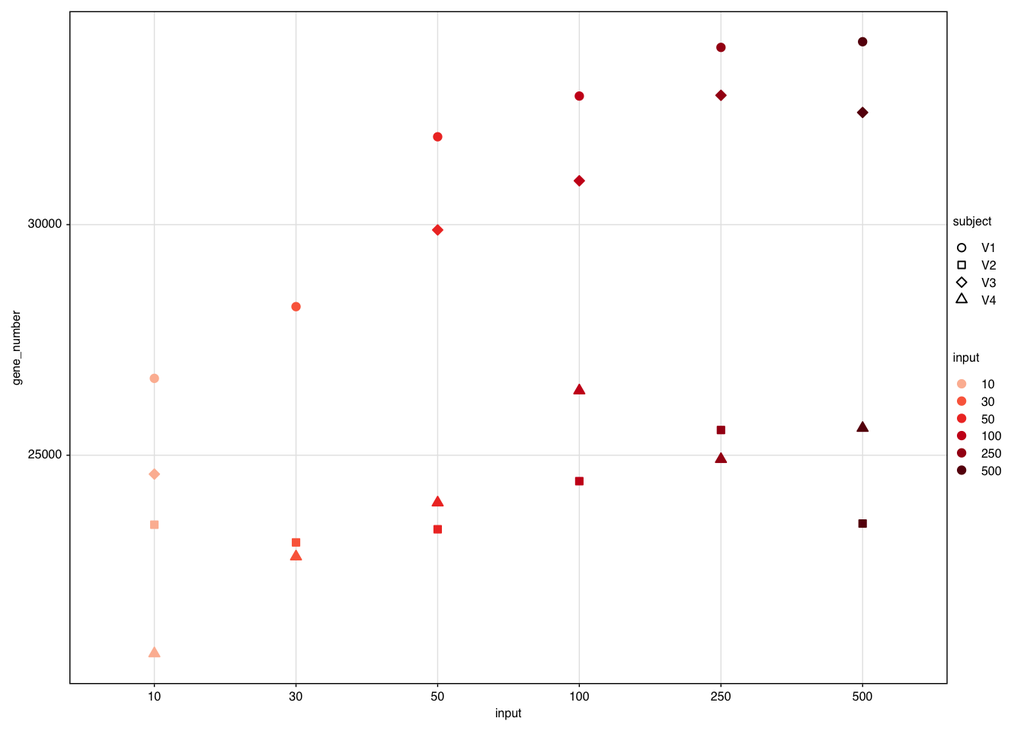

```r
ggplot(qc.tb, aes(x = input,
                       y = gene_number,
                       color = input,
                  fill = input,
                   shape = subject
                  )
            ) +
  geom_point() +
  #scale_color_viridis_d() +
  #scale_color_manual(values = palette_pca) +  # Apply the custom color palette
  ggplot2::scale_shape_manual(values = c(21:25)) +
  ggplot2::scale_color_manual(values = palette_pca) +
  ggplot2::scale_fill_manual(values = palette_pca) +
  gg_theme() + theme(legend.position = "right")
```

Save plot

```r
filename <- "QC_plot_gene_number"
for (file_format in file_formats) {
  ggsave_fixed(
    paste0(
      "../03_figures/",
      filename_prefix,
      filename, ".",
      file_format
    ),
    units = "mm",
    plot_width = 30,
    plot_height = 30,
    width = 60,
    height = 60
  )
}
```

## 5.2 Number of protein-coding genes detected

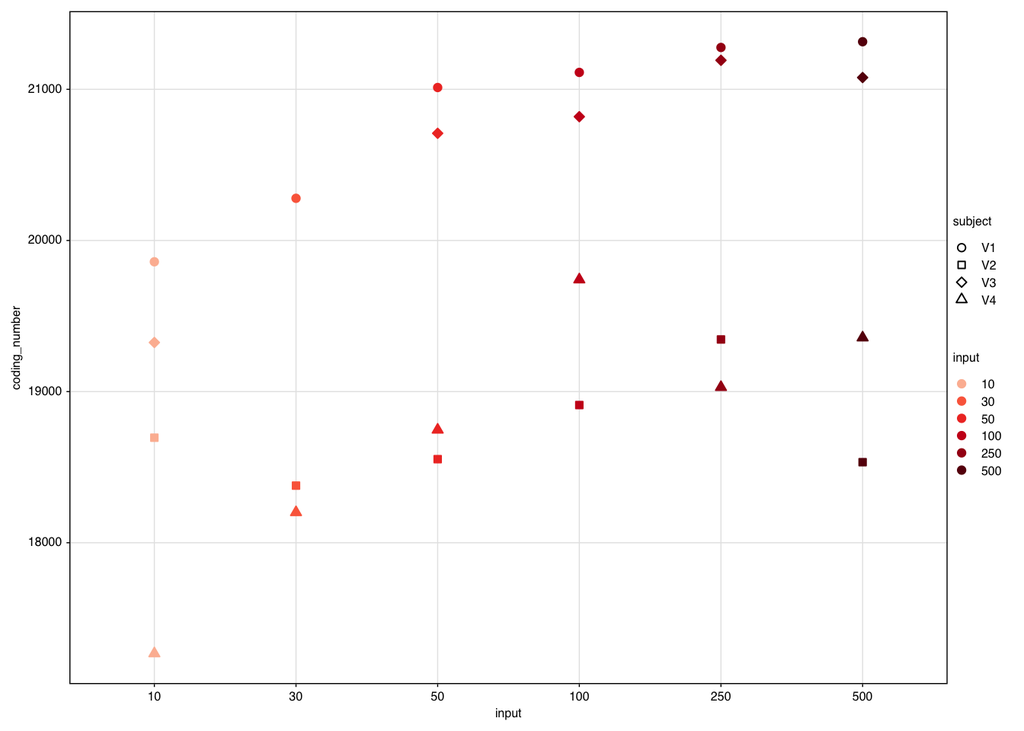

```r
ggplot(qc.tb, aes(x = input,
                       y = coding_number,
                       color = input,
                  fill = input,
                   shape = subject
                  )
            ) +
  geom_point() +
  #scale_color_viridis_d() +
  #scale_color_manual(values = palette_pca) +  # Apply the custom color palette
  ggplot2::scale_shape_manual(values = c(21:25)) +
  ggplot2::scale_color_manual(values = palette_pca) +
  ggplot2::scale_fill_manual(values = palette_pca) +
  gg_theme() + theme(legend.position = "right")
```

Save plot

```r
filename <- "QC_plot_protein_coding_number"
for (file_format in file_formats) {
  ggsave_fixed(
    paste0(
      "../03_figures/",
      filename_prefix,
      filename, ".",
      file_format
    ),
    units = "mm",
    plot_width = 30,
    plot_height = 30,
    width = 60,
    height = 60
  )
}
```

## 5.3 Proportion of reads from mitochondrial-encoded genes

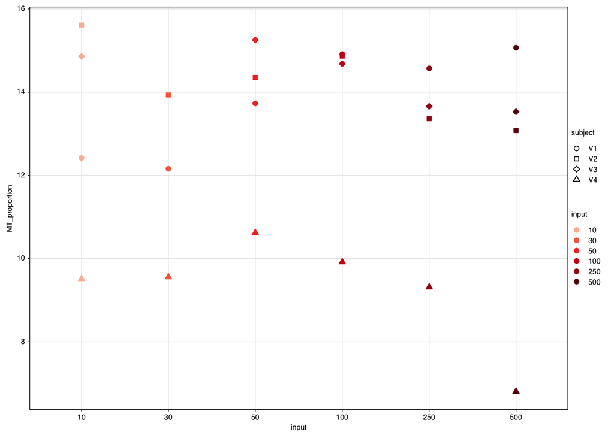

```r
ggplot(qc.tb, aes(x = input,
                       y = MT_proportion,
                       color = input,
                  fill = input,
                   shape = subject
                  )
            ) +
  geom_point() +
  #scale_color_viridis_d() +
  #scale_color_manual(values = palette_pca) +  # Apply the custom color palette
  ggplot2::scale_shape_manual(values = c(21:25)) +
  ggplot2::scale_color_manual(values = palette_pca) +
  ggplot2::scale_fill_manual(values = palette_pca) +
  gg_theme() + theme(legend.position = "right")
```

Save plot

```r
filename <- "QC_plot_MT_proportion"
for (file_format in file_formats) {
  ggsave_fixed(
    paste0(
      "../03_figures/",
      filename_prefix,
      filename, ".",
      file_format
    ),
    units = "mm",
    plot_width = 30,
    plot_height = 30,
    width = 60,
    height = 60
  )
}
```

## 5.4 Proportion of reads from ribo-related genes

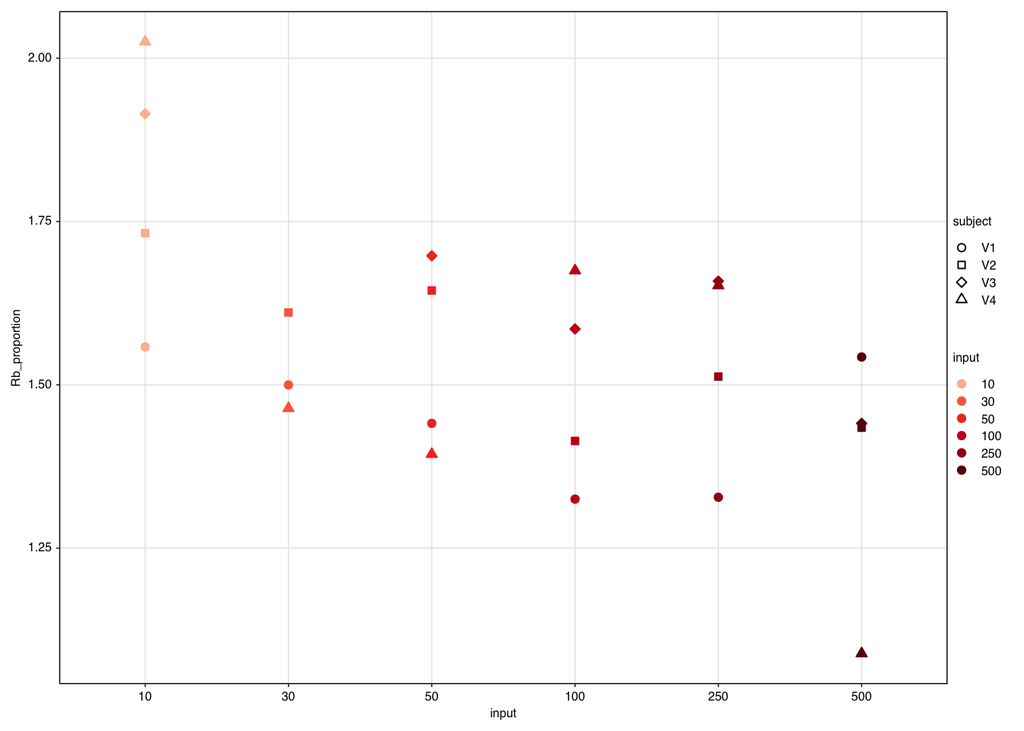

```r
ggplot(qc.tb, aes(x = input,
                       y = Rb_proportion,
                       color = input,
                  fill = input,
                   shape = subject
                  )
            ) +
  geom_point() +
  #scale_color_viridis_d() +
  #scale_color_manual(values = palette_pca) +  # Apply the custom color palette
  ggplot2::scale_shape_manual(values = c(21:25)) +
  ggplot2::scale_color_manual(values = palette_pca) +
  ggplot2::scale_fill_manual(values = palette_pca) +
  gg_theme() + theme(legend.position = "right")
```

Save plot

```r
filename <- "QC_plot_Rb_proportion"
for (file_format in file_formats) {
  ggsave_fixed(
    paste0(
      "../03_figures/",
      filename_prefix,
      filename, ".",
      file_format
    ),
    units = "mm",
    plot_width = 30,
    plot_height = 30,
    width = 60,
    height = 60
  )
}
```

# 6 PCA plot

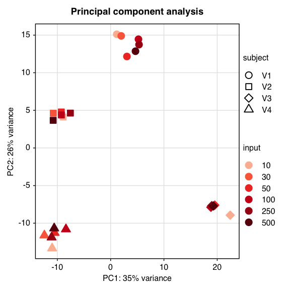

```r
#palette_pca <- c("#1F78B4", "#E31A1C", "#FDBF6F", "#CAB2D6")
#scico_palette_show(n = 3, palette = "navia")
#palette_pca <- scico(3, palette = "navia")
variable1 <- "subject"
variable2 <- "input"

palette_pca <- c("#FCBBA1", "#FB6A4A", "#EF3B2C",
                 "#CB181D","#A50F15", "#67000D")
#palette_pca <- brewer.pal(n = 6, name = "Reds")
# [1] "#FFF5F0" "#FEE0D2" "#FCBBA1" "#FC9272" "#FB6A4A" "#EF3B2C" "#CB181D" "#A50F15"
# [9] "#67000D"

vsd <- DESeq2::vst(dds, blind = FALSE)
pca_data <- DESeq2::plotPCA(vsd,
                            intgroup = c(variable1, variable2),
                            returnData = TRUE)
percent_var <- round(100 * attr(pca_data, "percentVar"))

pca <- pca_data %>%
  ggplot2::ggplot(ggplot2::aes(PC1, PC2)) +
  # ggplot2::geom_point(size = 2)
  ggplot2::geom_point(
    aes(
      color = !!as.symbol(variable2),
      fill = !!as.symbol(variable2),
      shape = !!as.symbol(variable1)
    ),
    size = 2,
    # shape = 21,
    #color = "black",
  ) +
  # ggplot2::scale_shape_manual(values = c(0,1,2,5,6,7,9,10))

  ggplot2::xlab(paste0("PC1: ", percent_var[1], "% variance")) +
  ggplot2::ylab(paste0("PC2: ", percent_var[2], "% variance")) +
  gg_theme() +
  ggplot2::theme(legend.position = "right") +
  ggplot2::scale_shape_manual(values = c(21:25)) +
  ggplot2::scale_color_manual(values = palette_pca) +
  ggplot2::scale_fill_manual(values = palette_pca) +
  ggtitle("**Principal component analysis**")
pca
```

```r
# Save plot
filename <- "PCA_plot_kallisto_counts"
for (file_format in file_formats) {
  ggsave_fixed(
    paste0(
      "../03_figures/",
      filename_prefix,
      filename, ".",
      file_format
    ),
    units = "mm",
    plot_width = 40,
    plot_height = 40,
    width = 60,
    height = 60
  )
}
```

```
## Saved file : ../03_figures/PCA_plot_kallisto_counts.pdf
```

## 6.1 PCA plot with labels

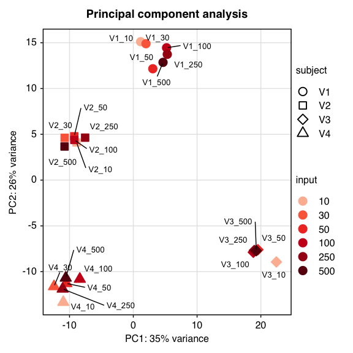

```r
pca +
  geom_text_repel(
    aes(label = name),
    size = 5 / ggplot2:::.pt,
    nudge_x = 0.6,
    #nudge_y = 0.3,
    force = 40,
    #force_pull = 10,
    max.overlaps = 20,
    segment.size = 0.25,
    segment.colour = "black"
  )
```

Save plot

```r
filename <- "PCA_plot_kallisto_counts_labels"
for (file_format in file_formats) {
  ggsave_fixed(
    paste0(
      "../03_figures/",
      filename_prefix,
      filename, ".",
      file_format
    ),
    units = "mm",
    plot_width = 40,
    plot_height = 40,
    width = 60,
    height = 60
  )
}
```

```
## Saved file : ../03_figures/PCA_plot_kallisto_counts_labels.pdf
```

### 6.1.1 Sample-to-sample distances

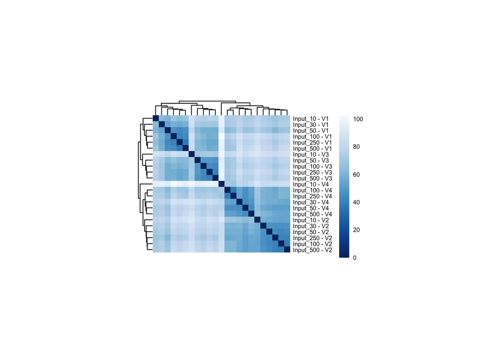

```r
vsd <- vst(dds, blind = FALSE)
sampleDists <- dist(t(assay(vsd)))
sampleDistMatrix <- as.matrix(sampleDists)
rownames(sampleDistMatrix) <- paste0("Input_",vsd$input, " - ", vsd$subject)
colnames(sampleDistMatrix) <- NULL
colors <- colorRampPalette(rev(brewer.pal(9, "Blues")))(255)
heatmap <- pheatmap::pheatmap(sampleDistMatrix,
  clustering_distance_rows = sampleDists,
  clustering_distance_cols = sampleDists,
  show_rownames = T, show_colnames = T,
  cellwidth = 6,
  cellheight = 6,
  treeheight_row = 10,
  treeheight_col = 10,
  fontsize = 6,
  border_color = NA,
  col = colorRampPalette(rev(brewer.pal(9, "Blues")))(255)
)
```

```r
# Save plot
filename <- "sample_distances"
for (file_format in file_formats) {
  ggsave(
    plot = heatmap,
    paste0(
      "../03_figures/",
      filename_prefix,
      filename, ".",
      file_format
    ),
    units = "mm",
    dpi = 300,
    width = 4 * length(metadata$sample),
    height = 3 * length(metadata$sample)
  )
}
```

```
## Saved file : ../03_figures/sample_distances.pdf
```

### 6.1.2 Normalized counts

```r
# Create data frame for normalize counts
normalized_counts <- annotation_tx2gene %>%
  inner_join((data.frame(
    counts(dds, normalized = T)
  ) %>%
    rownames_to_column("ensembl_gene_id")), by = "ensembl_gene_id") %>%
  arrange(ensembl_gene_id)

# Save normalized counts
filename <- "normalized_counts"
write.csv(normalized_counts, paste0(
  "../02_results/deseq2/",
  filename_prefix,
  filename,
  ".csv"
),
row.names = F, quote = F
)

saveRDS(normalized_counts, paste0(
  "../02_results/deseq2/",
  filename_prefix,
  filename,
  ".RDS"
))
```

# 7 Supplementary table

```r
filename <- "normalized_gene_counts"

excel <- list(
  normalized_counts = normalized_counts
)

write_xlsx(excel, paste0(
  "../04_supplements/",
  filename_prefix,
  filename,
  ".xlsx"
))
```

```
## Saved file : ../04_supplements/normalized_gene_counts.xlsx
```

## 7.1 QC table

```r
filename <- "qc_table"

excel <- list(
  QC_table = qc.tb
)

write_xlsx(excel, paste0(
  "../04_supplements/",
  filename_prefix,
  filename,
  ".xlsx"
))
```

# 9 References

- Love MI, Huber W, Anders S. 2014. Moderated estimation of fold change and dispersion for RNA-seq data with DESeq2. Genome Biol 15:550. [Link](https://doi.org/10.1186/s13059-014-0550-8)

[RNA-seq workflow: gene-level exploratory analysis and differential expression](https://bioconductor.org/help/course-materials/2022/CSAMA/lab/2-tuesday/lab-03-rnaseq/rnaseqGene_CSAMA2022.html)

[Analyzing RNA-seq data with DESeq2](https://www.bioconductor.org/packages/devel/bioc/vignettes/DESeq2/inst/doc/DESeq2.html)